# Template for 2D data analysis with INLABru

J Matthiopoulos (collated from INLABru vignettes)

2022-05-27

## Setting up

The libraries needed

```r
library(sf)
library(raster)
library(rmapshaper)
library(tidyr)
library(ggplot2)
```

## Importing the data

The necessary geographic data are in package `raster`. The `getData` command fetches geographic data for anywhere in the world. Data are read from files that are first downloaded if necessary. The data names are as follows:

- `alt`: Altitude (elevation); the data were aggregated from SRTM 90 m resolution data between -60 and 60 latitude.
- `GADM`: A database of global administrative boundaries.
- `worldclim`: A database of global interpolated climate data.
- `SRTM`: The hole-filled CGIAR-SRTM digital elevation (90 m resolution).
- `countries`: Polygons for all countries at a higher resolution than the `wrld_simpl` data in the maptools package.

Note that the `terra` package, that is compatible with the new changes in GDAL and PROJ, has now been created as a replacement for the raster library. I will need to explore equivalent ways of obtaining these data via `terra`.

```r
uk_mask <- getData('GADM', country='GBR', level=1)
England <- uk_mask[uk_mask$NAME_1 == "England",]
class(England)
```

```
## [1] "SpatialPolygonsDataFrame"
## attr(,"package")
## [1] "sp"
```

Any shape file in my system can be read directly using the `st_read()` (an `sf` commnand for reading simple features from files or databases, or retrieving layer names and their geometry type(s)). In this example, the England SpatialPolygonsDataFrame will be converted to a simple feature object that we can manipulate and visualize within the tidyverse DSLs. The CRS for spatial objects of class `sf` or `stars` can be retrieved using the `st_crs` function, or be set or changed via `st_set_crs` using pipeline command (notice that simply replacing the CRS does not re-project the data, we should use `st_transform` for this).

In the code below st_transform() (Equivalent to spTransform()) is used to project the original CRS using the EPSG code for the BNG and change the units from meters to km by accessing the PROJ.4 string attribute.

```r
# build an sf object
England_sf = st_as_sf(England) %>%  st_transform(crs = 27700)
England_sf = st_transform(England_sf,gsub("units=m","units=km",st_crs(England_sf)$proj4string))
```

For simplicity, remove all of the smaller detached islands by using the `ms_filter_islands` function in the `rmapshaper` package [^1]

```r
# Remove detached polygons with an area less than 2000 km
England_mainland <- ms_filter_islands(England_sf, min_area = 2000)
England_mainland
```

|  | GID_0 | NAME_0 | GID_1 | NAME_1 | VARNAME_1 | NL_NAME_1 | TYPE_1 | ENGTYPE_1 | CC_1 | HASC_1 | geometry |
| --- | --- | --- | --- | --- | --- | --- | --- | --- | --- | --- | --- |
| 1 | GBR | United Kingdom | GBR.1_1 | England | NA | NA | Home Nation\|Constituent Country | Kingdom | NA | NA |  |

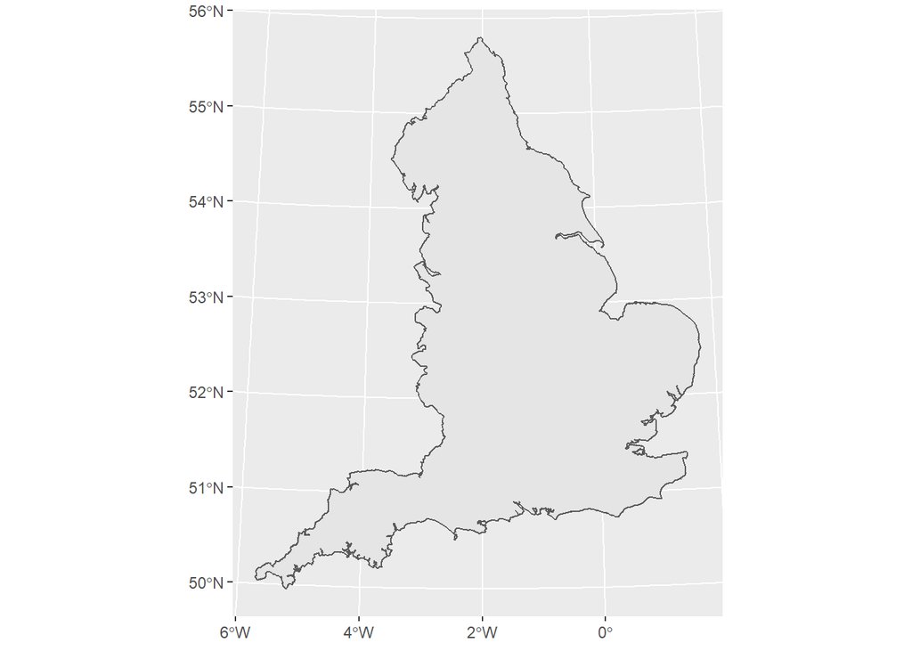

```r
#Plot the resulting simple feature object using geom_sf within ggplot.
ggplot()+
  geom_sf(data=England_mainland)
```

We can query information on the CRS and projection as follows:

```r
#  retrieve the PROJ.4 attribute
st_crs(England_mainland)$proj4string
```

```
## [1] "+proj=tmerc +lat_0=49 +lon_0=-2 +k=0.9996012717 +x_0=400000 +y_0=-100000 +ellps=airy +units=km +no_defs"
```

```r
# check whether  longitude-latitude projection is still being applied
st_is_longlat(England_mainland)
```

```
## [1] FALSE
```

```r
# Check the spatial units of our projection
st_crs(England_mainland)$units
```

```
## [1] "km"
```

[^1]: This package fully supports sf or sfc polygons object as well. It is used to edit and simplify `geojson`, `Spatial`, and `sf` objects. Performs topologically-aware polygon simplification, as well as other operations such as clipping, erasing, dissolving, and converting ‘multi-part’ to ‘single-part’ geometries. It relies on the `geojsonio` package for working with `geojson` objects, the `sf` package for working with `sf` objects, and the `sp` and `rgdal` packages for working with `Spatial` objects.